# Assignment B

## Instructions

1. You may talk to a friend, discuss the questions and potential directions for solving them. However, you need to write your own solutions and code separately, and not as a group activity.
2. Do not write your name on the assignment.
3. Write your code in the *Code* cells and your answer in the *Markdown* cells of the Jupyter notebook. Ensure that the solution is written neatly enough to understand and grade.
4. Use [Quarto](https://quarto.org/docs/output-formats/html-basics.html) to print the *.ipynb* file as HTML. You will need to open the command prompt, navigate to the directory containing the file, and use the command: `quarto render filename.ipynb --to html`. Submit the HTML file.
5. The assignment is worth 100 points, and is due on **Thursday, 26th January 2023 at 11:59 pm**.
6. **Five points are properly formatting the assignment**. The breakdown is as follows:
- Must be an HTML file rendered using Quarto (1 pt). *If you have a Quarto issue, you must mention the issue & quote the error you get when rendering using Quarto in the comments section of Canvas, and submit the ipynb file.*
- No name can be written on the assignment, nor can there be any indicator of the student’s identity—e.g. printouts of the working directory should not be included in the final submission (1 pt)
- There aren’t excessively long outputs of extraneous information (e.g. no printouts of entire data frames without good reason, there aren’t long printouts of which iteration a loop is on, there aren’t long sections of commented-out code, etc.) (1 pt)
- Final answers of each question are written in Markdown cells (1 pt).
- There is no piece of unnecessary / redundant code, and no unnecessary / redundant text (1 pt)

```python
import pandas as pd
import numpy as np
import statsmodels.formula.api as smf
import seaborn as sns
import matplotlib.pyplot as plt
```

## Multiple linear regression

A study was conducted on 97 men with prostate cancer who were due to receive a radical prostatectomy. The dataset *prostate.csv* contains data on 9 measurements made on these 97 men. The description of variables can be found [here](https://rafalab.github.io/pages/649/prostate.html):

```python
prostate_df = pd.read_csv('prostate.csv')
```

### Training MLR

Fit a linear regression model with `lpsa` as the response and all the other variables as predictors. Write down the equation to predict `lpsa` based on the other eight variables.

*(2+2 points)*

```python
model = smf.ols(formula = 'lpsa~pgg45+gleason+lcp+svi+lbph+age+lweight+lcavol', data = prostate_df).fit()
print(model.summary())
```

```
                            OLS Regression Results
==============================================================================
Dep. Variable:                   lpsa   R-squared:                       0.655
Model:                            OLS   Adj. R-squared:                  0.623
Method:                 Least Squares   F-statistic:                     20.86
Date:                Sun, 29 Jan 2023   Prob (F-statistic):           2.24e-17
Time:                        19:45:31   Log-Likelihood:                -99.476
No. Observations:                  97   AIC:                             217.0
Df Residuals:                      88   BIC:                             240.1
Df Model:                           8
Covariance Type:            nonrobust
==============================================================================
                 coef    std err          t      P>|t|      [0.025      0.975]
------------------------------------------------------------------------------
Intercept      0.6693      1.296      0.516      0.607      -1.907       3.246
pgg45          0.0045      0.004      1.024      0.309      -0.004       0.013
gleason        0.0451      0.157      0.287      0.775      -0.268       0.358
lcp           -0.1055      0.091     -1.159      0.250      -0.286       0.075
svi            0.7662      0.244      3.136      0.002       0.281       1.252
lbph           0.1071      0.058      1.832      0.070      -0.009       0.223
age           -0.0196      0.011     -1.758      0.082      -0.042       0.003
lweight        0.4545      0.170      2.673      0.009       0.117       0.792
lcavol         0.5870      0.088      6.677      0.000       0.412       0.762
==============================================================================
Omnibus:                        0.235   Durbin-Watson:                   1.507
Prob(Omnibus):                  0.889   Jarque-Bera (JB):                0.026
Skew:                          -0.017   Prob(JB):                        0.987
Kurtosis:                       3.073   Cond. No.                     1.28e+03
==============================================================================

Notes:
[1] Standard Errors assume that the covariance matrix of the errors is correctly specified.
[2] The condition number is large, 1.28e+03. This might indicate that there are
strong multicollinearity or other numerical problems.
```

#### estimated level of prostate specific antigen = 0.6693 + (0.0045 * pgg45) + (0.0451 * gleason) + (-0.1055 * lcp) + (0.7662 * svi) + (0.1071 * lbph) + (-0.0196 * age) + (0.4545 * lweight) + (0.5870 * lcavol)

### Model significance

Is the overall regression significant at 5% level? Justify your answer.

*(2 points)*

#### Using the Prob (F-statistic) value, we can see that it is close to 0 and definitely < 0.05. This p-value is the probability that the null hypothesis (all coefficients not being statistically significant) for the full model is true. Since this value is approximately 0 and less than 0.05, we can reject the null hypothesis. There is evidence that suggests there is a linear relationship between level of prostate specific antigen and the set of predictor variables.

### Coefficient interpretation

Interpret the coefficient of `svi`.

*(2 points)*

#### The coefficient of the svi variable is 0.7662. This means that for a one unit increase in seminal vesicle invasion, the level of prostate specific antigen will increase by 0.7662 units, while holding all other predictor variables constant.

### Variable significance

Report the $p$-values for `gleason` and `age`. What do you conclude about the significance of these variables?

*(2+2 points)*

#### The p-value for gleason is 0.775 and the p-value for age is 0.082. Both these values are greater than 0.05, which means there is not enough evidence to reject the null hypothesis that these corresponding coefficients are zero, and suggests that these variables do not have a statisically significant effect on the lpsa variable. It also means that there is no relationship or a weak relationship between the gleason/age and the lpsa and that this relationship is likely to be due to chance.

### Variable significance from confidence interval

What is the 95% confidence interval for the coefficient of `age`? Can you conclude anything about its significance based on the confidence interval?

*(2+2 points)*

```python
confidence_interval_age = [-0.0196 - 2 * 0.011, -0.0196 + 2 * 0.011]
print('The confidence interval for the age coefficient is:',confidence_interval_age)
```

```
The confidence interval for the age coefficient is: [-0.0416, 0.0023999999999999994]
```

#### Since this confidence interval includes 0, we can conclude that it is a non-significant predictor variable. The fact that confidence interval includes 0 means the coefficient is not statistically different from 0, which means no effect on the response variable lpsa, with a probability of 95%.

### $p$-value

Fit a simple linear regression on `lpsa` against `gleason`. What is the $p$-value for `gleason`?

*(1+1 points)*

```python
simple_model = smf.ols(formula='lpsa ~ gleason', data=prostate_df).fit()
print(simple_model.summary())
```

```
                            OLS Regression Results
==============================================================================
Dep. Variable:                   lpsa   R-squared:                       0.136
Model:                            OLS   Adj. R-squared:                  0.127
Method:                 Least Squares   F-statistic:                     14.97
Date:                Sun, 29 Jan 2023   Prob (F-statistic):           0.000200
Time:                        19:46:39   Log-Likelihood:                -143.96
No. Observations:                  97   AIC:                             291.9
Df Residuals:                      95   BIC:                             297.1
Df Model:                           1
Covariance Type:            nonrobust
==============================================================================
                 coef    std err          t      P>|t|      [0.025      0.975]
------------------------------------------------------------------------------
Intercept     -1.5044      1.035     -1.453      0.149      -3.559       0.550
gleason        0.5898      0.152      3.869      0.000       0.287       0.892
==============================================================================
Omnibus:                        2.099   Durbin-Watson:                   0.245
Prob(Omnibus):                  0.350   Jarque-Bera (JB):                1.526
Skew:                           0.178   Prob(JB):                        0.466
Kurtosis:                       3.501   Cond. No.                         65.6
==============================================================================

Notes:
[1] Standard Errors assume that the covariance matrix of the errors is correctly specified.
```

#### The p-value of gleason is 0.

### Predictor significance in presence / absence of other predictors

Is the predictor `gleason` statistically significant in the model developed in the previous question *(B.1.6)*?

Was `gleason` statistically significant in the model developed in the first question *(B.1.1)* with multiple predictors?

Did the statistical significance of `gleason` change in the absence of other predictors? Why or why not?

*(1+1+4 points)*

#### Yes. The predictor variable gleason is statistically significant in the model developed because it is 0 which is less than 0.05.

#### No. It’s p-value from that model was 0.775 which is greater than 0.05.

#### Yes. Unlike in the first model, gleason is statistically significant in absence of other predictors. A possibility for this change could be correlation with other variables. A variable might not be considered statistically significant when considered alongside other correlated variables. In an SLR, this variable’s correlation with other variables is not considered.

### Prediction

Predict `lpsa` of a 65-year old man with `lcavol` = 1.35, `lweight` = 3.65, `lbph` = 0.1, `svi` = 0.22, `lcp` = -0.18, `gleason` = 6.75, and `pgg45` = 25 and find 95% prediction intervals.

*(2 points)*

```python
model_df = pd.DataFrame({'lcavol': [1.35], 'lweight': [3.65], 'lbph': [0.1], 'age': [65], 'svi': [0.22], 'lcp': [-0.18], 'gleason': [6.75], 'pgg45': [25]})
prediction_value = model.predict(model_df)
prediction = model.get_prediction(model_df)
prediction_value
```

```
0    2.460288
dtype: float64
```

```python
pred_summary = prediction.summary_frame(alpha=0.05)
conf_interval = pred_summary[['mean_ci_lower','mean_ci_upper']]
pred_interval = pred_summary[['obs_ci_lower', 'obs_ci_upper']]
print(conf_interval)
print(pred_interval)
```

```
   mean_ci_lower  mean_ci_upper
0       2.315113       2.605463
   obs_ci_lower  obs_ci_upper
0      1.044995       3.87558
```

#### The estimated level of prostate specific antigen for this individual is 2.460288. The 95% confidence interval for this estimation is [[2.315113, 2.605463]] and the 95% prediction interval for this estimate is [[1.044995, 3.87558]]

### Variable selection

Find the largest subset of predictors in the model developed in the first question *(B.1.1)*, such that their coefficients are zero, i.e., none of the predictors in the subset are statistically significant.

Does the model $R$-squared change a lot if you remove the set of predictors identifed above from the model in the first question *(B.1.1)*?

**Hint:** You may use the `f_test()` method to test hypotheses.

*(4+1 points)*

```python
model_subset = smf.ols(formula = 'lpsa ~ pgg45 + gleason + lcp + lbph + age', data = prostate_df).fit()
# Creating a string containing the predictor variables
predictors = 'pgg45 + gleason + lcp + lbph + age'

# Using the f_test method to test the hypothesis that the predictors are non-significant
hypothesis = '{} = 0'.format(predictors)
f_test = model_subset.f_test(hypothesis)
print(f_test)
```

```
<F test: F=7.974216236927657, p=0.005829072323112683, df_denom=91, df_num=1>
```

```python
model_significant = smf.ols(formula = 'lpsa~svi+lweight+lcavol', data=prostate_df).fit()
print(model_significant.summary())
```

```
                            OLS Regression Results
==============================================================================
Dep. Variable:                   lpsa   R-squared:                       0.626
Model:                            OLS   Adj. R-squared:                  0.614
Method:                 Least Squares   F-statistic:                     51.99
Date:                Sun, 29 Jan 2023   Prob (F-statistic):           8.05e-20
Time:                        19:47:33   Log-Likelihood:                -103.30
No. Observations:                  97   AIC:                             214.6
Df Residuals:                      93   BIC:                             224.9
Df Model:                           3
Covariance Type:            nonrobust
==============================================================================
                 coef    std err          t      P>|t|      [0.025      0.975]
------------------------------------------------------------------------------
Intercept     -0.2681      0.543     -0.493      0.623      -1.347       0.811
svi            0.6662      0.210      3.176      0.002       0.250       1.083
lweight        0.5085      0.150      3.386      0.001       0.210       0.807
lcavol         0.5516      0.075      7.388      0.000       0.403       0.700
==============================================================================
Omnibus:                        0.647   Durbin-Watson:                   1.467
Prob(Omnibus):                  0.723   Jarque-Bera (JB):                0.776
Skew:                          -0.118   Prob(JB):                        0.679
Kurtosis:                       2.631   Cond. No.                         31.6
==============================================================================

Notes:
[1] Standard Errors assume that the covariance matrix of the errors is correctly specified.
```

#### The R-squared value does not change that much at all. One reason could be that non-significant predictors may have a low correlation with the response variable and therefore not contribute much to the model’s R-squared value. Additionally, other predictors in the model may take on a larger role in explaining the response variable, thus compensating for the removed predictor’s lack of contribution to the R-squared value.

## Using MLR coefficients and variable transformation

The dataset *infmort.csv* gives the infant mortality of different countries in the world. The column `mortality` contains the infant mortality in deaths per 1000 births.

```python
infmort_df = pd.read_csv('infmort.csv')
```

### Data visualisation

Make the following plots:

1. a boxplot of log(`mortality`) against `region` *(note that a plot of log(`mortality`) against `region` better distinguishes the mortality among regions as compared to a plot of `mortality` against `region`*,
2. a boxplot of `income` against `region`, and
3. a scatter plot of `mortality` against `income`.

What trends do you see in these plots? *Mention the trend separately for each plot.*

*(3+2 points)*

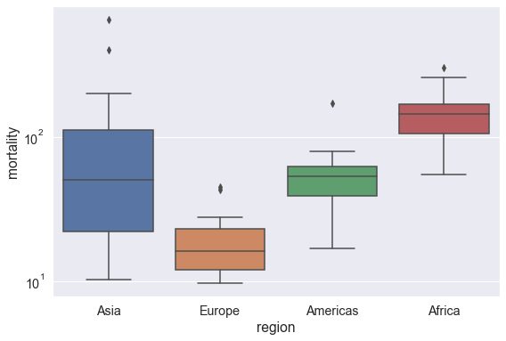

```python
sns.boxplot(x='region', y='mortality', data=infmort_df)
plt.yscale('log')
plt.show()
```

#### In this trend, Europe has both the lowest mortality rates in general as well as the least amount of spread between mortality rates in these countries. Asia and the Americas have similar median values but Asia offers the most spread both in terms of outliers and the interquartile range. Africa generally has the countries with the highest infant mortality ratess but Asia has two countries with higher infant mortality rates than the highest mortality value for Africa.

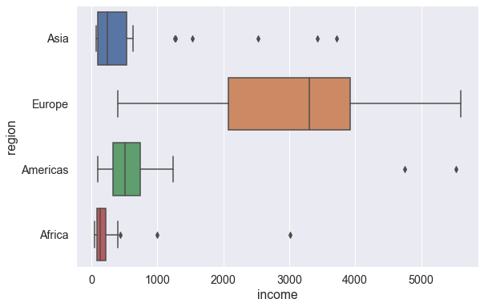

```python
sns.boxplot(x='income', y='region', data=infmort_df)
plt.show()
```

#### In this visualization, we see that Europe by far enjoys the most income compared to other regions, even when factoring in the large variation from the 25th percentile to the 75th percentile. The other regions, when compared to Europe, are comprised of countries where people are making low incomes, with the exception of some outliers where people in these countries seem to be making comparable or even better income when compared to European countries.

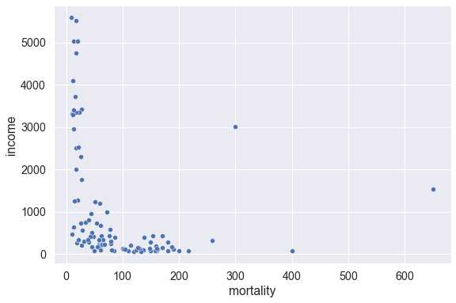

```python
sns.scatterplot(x='mortality', y='income', data=infmort_df)
plt.show()
```

#### With a few exceptions of countries with high mortality rates despite relatively high incomes, the countries that have the highest mortality rates are generally clustered around the lower income ranges, with most countries having very minimal rates of infant mortality especially after income exceeds the $1000 value.

### Removing effect of predictor from response

Europe seems to have the lowest infant mortality, but it also has the highest per capita annual income. We want to see if Europe still has the lowest mortality if we remove the effect of income from the mortality. We will answer this question with the following steps.

#### Variable transformation

Plot:

1. `mortality` against `income`,
2. log(`mortality`) against `income`,
3. `mortality` against log(`income`), and
4. log(`mortality`) against log(`income`).

Based on the plots, postulate an appropriate model to predict mortality as a function of income. *Print the model summary.*

*(2+4 points)*

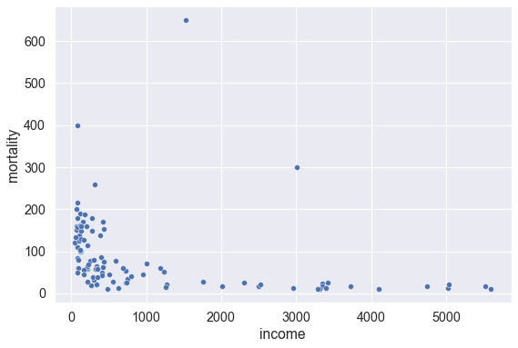

```python
sns.scatterplot(x='income', y='mortality', data=infmort_df)
plt.show()
```

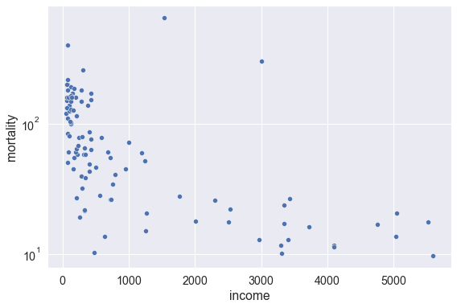

```python
sns.scatterplot(x='income', y='mortality', data=infmort_df)
plt.yscale('log')
plt.show()
```

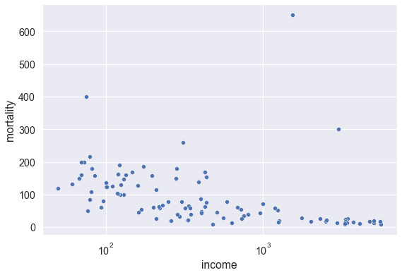

```python
sns.scatterplot(x='income', y='mortality', data=infmort_df)
plt.xscale('log')
plt.show()
```

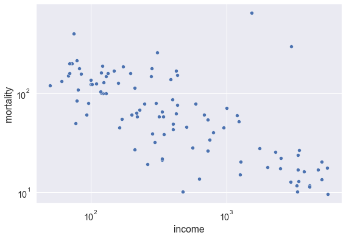

```python
sns.scatterplot(x='income', y='mortality', data=infmort_df)
plt.xscale('log')
plt.yscale('log')
plt.show()
```

```python
model = smf.ols("np.log(mortality) ~ np.log(income)", data=infmort_df).fit()
print(model.summary())
```

```
                            OLS Regression Results
==============================================================================
Dep. Variable:      np.log(mortality)   R-squared:                       0.502
Model:                            OLS   Adj. R-squared:                  0.497
Method:                 Least Squares   F-statistic:                     99.84
Date:                Sun, 29 Jan 2023   Prob (F-statistic):           1.14e-16
Time:                        19:47:45   Log-Likelihood:                -104.34
No. Observations:                 101   AIC:                             212.7
Df Residuals:                      99   BIC:                             217.9
Df Model:                           1
Covariance Type:            nonrobust
==================================================================================
                     coef    std err          t      P>|t|      [0.025      0.975]
----------------------------------------------------------------------------------
Intercept          7.1458      0.317     22.575      0.000       6.518       7.774
np.log(income)    -0.5118      0.051     -9.992      0.000      -0.613      -0.410
==============================================================================
Omnibus:                       38.668   Durbin-Watson:                   1.898
Prob(Omnibus):                  0.000   Jarque-Bera (JB):              129.408
Skew:                           1.255   Prob(JB):                     7.93e-29
Kurtosis:                       7.945   Cond. No.                         29.3
==============================================================================

Notes:
[1] Standard Errors assume that the covariance matrix of the errors is correctly specified.
```

#### Model update

Update the model developed in the previous question by adding `region` as a predictor. Print the model summary.

*(2 points)*

```python
model = smf.ols("np.log(mortality) ~ np.log(income)+region", data=infmort_df).fit()
print(model.summary())
```

```
                            OLS Regression Results
==============================================================================
Dep. Variable:      np.log(mortality)   R-squared:                       0.616
Model:                            OLS   Adj. R-squared:                  0.600
Method:                 Least Squares   F-statistic:                     38.55
Date:                Sun, 29 Jan 2023   Prob (F-statistic):           3.29e-19
Time:                        19:47:47   Log-Likelihood:                -91.189
No. Observations:                 101   AIC:                             192.4
Df Residuals:                      96   BIC:                             205.5
Df Model:                           4
Covariance Type:            nonrobust
======================================================================================
                         coef    std err          t      P>|t|      [0.025      0.975]
--------------------------------------------------------------------------------------
Intercept              6.4030      0.358     17.871      0.000       5.692       7.114
region[T.Americas]    -0.6022      0.190     -3.166      0.002      -0.980      -0.225
region[T.Asia]        -0.7233      0.163     -4.431      0.000      -1.047      -0.399
region[T.Europe]      -1.2028      0.259     -4.647      0.000      -1.717      -0.689
np.log(income)        -0.2994      0.067     -4.441      0.000      -0.433      -0.166
==============================================================================
Omnibus:                       44.959   Durbin-Watson:                   1.847
Prob(Omnibus):                  0.000   Jarque-Bera (JB):              174.758
Skew:                           1.428   Prob(JB):                     1.13e-38
Kurtosis:                       8.777   Cond. No.                         42.8
==============================================================================

Notes:
[1] Standard Errors assume that the covariance matrix of the errors is correctly specified.
```

Use the model developed in the previous question to compute `adjusted_mortality` for each observation in the data, where adjusted mortality is the mortality after removing the estimated effect of income. Make a boxplot of log(`adjusted_mortality`) against `region`.

*(4+2 points)*

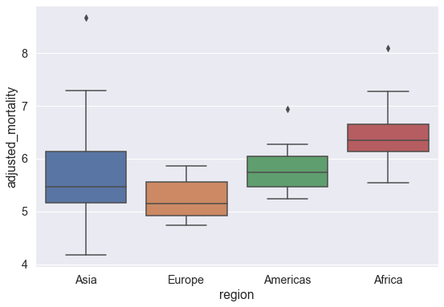

```python
infmort_df['adjusted_mortality'] = np.exp(np.log(infmort_df.mortality) - model.params['np.log(income)']*np.log(infmort_df.income))
sns.boxplot(x="region", y=np.log(infmort_df.adjusted_mortality), data=infmort_df)
```

### Data visualisation after removing effect of predictor from response

From the plot in the previous question:

1. Does Europe still seem to have the lowest mortality as compared to other regions after removing the effect of income from mortality?
2. After adjusting for income, is there any change in the mortality comparison among different regions. Compare the plot developed in the previous question to the plot of `log(mortality)` against `region` developed earlier *(B.2.1)* to answer this question.

**Hint:** Do any African / Asian / American countries seem to do better than all the European countries with regard to mortality after adjusting for income?

*(1+3 points)*

#### Based on the median values, European countries seem to generally have the lowest mortality rates. This is backed up also by the fact that Europe’s plot also has the lowest first and third quartile values as well as the fact that it’s higheset value is the lowest when compared to the highest value of other regions.

#### For the Asia region, the IQR has been greatly reduced and the median mortality value is closer to that of Europe’s when compared to the previous plot. Unlike in the previous plot, Asia’s median mortality value is lower than that of the Americas plot. Additionally, the lowest mortality value in the entire plot belongs to an Asian country instead of a European country. Another change is that the difference between the lowest value in the America’s plot and its first quartile value has been greatly reduced.

## Variable transformations and interactions

The dataset *soc_ind.csv* contains the GDP per capita of some countries along with several social indicators.

```python
soc_ind = pd.read_csv('soc_ind.csv')
```

### Training SLR

For a simple linear regression model predicting `gdpPerCapita`. Which predictor will provide the best model fit *(ignore categorical predictors)*? Let that predictor be $P$.

*(2 points)*

```python
soc_ind.corrwith(soc_ind['gdpPerCapita']).abs().sort_values(ascending=False)[1:2]
```

```
lifeFemale    0.604029
dtype: float64
```

#### Based on the correlation coefficients, the female life expectancy variable has the greatest absolute value and thus has the strongest linear relationship with gdpPerCapita.

### Linearity in relationship

Make a scatterplot of `gdpPerCapita` vs $P$. Does the relationship between `gdpPerCapita` and $P$ seem linear or non-linear?

*(1 + 2 points)*

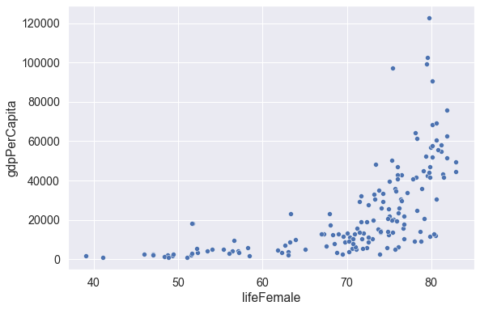

```python
sns.scatterplot(data=soc_ind, x='lifeFemale', y='gdpPerCapita')
plt.show()
```

#### This relationship is clearly non-linear. As the gdpPerCapita values increase, the differences between female life expectancies are decreasing so this is not a constant linear relationship.

### Variable transformation

If the relationship identified in the previous question is non-linear, identify and include transformation(s) of the predictor $P$ in the model to improve the model fit.

Mention the predictors of the transformed model, and report the change in the $R$-squared value of the transformed model as compared to the simple linear regression model with only $P$.

*(4+4 points)*

```python
simple_model = smf.ols(formula='gdpPerCapita ~ lifeFemale', data=soc_ind).fit()
print(simple_model.summary())
```

```
                            OLS Regression Results
==============================================================================
Dep. Variable:           gdpPerCapita   R-squared:                       0.365
Model:                            OLS   Adj. R-squared:                  0.361
Method:                 Least Squares   F-statistic:                     87.89
Date:                Sun, 29 Jan 2023   Prob (F-statistic):           8.77e-17
Time:                        19:48:34   Log-Likelihood:                -1743.3
No. Observations:                 155   AIC:                             3491.
Df Residuals:                     153   BIC:                             3497.
Df Model:                           1
Covariance Type:            nonrobust
==============================================================================
                 coef    std err          t      P>|t|      [0.025      0.975]
------------------------------------------------------------------------------
Intercept  -7.436e+04   1.06e+04     -7.002      0.000   -9.53e+04   -5.34e+04
lifeFemale  1398.2136    149.145      9.375      0.000    1103.564    1692.863
==============================================================================
Omnibus:                       59.449   Durbin-Watson:                   1.982
Prob(Omnibus):                  0.000   Jarque-Bera (JB):              168.079
Skew:                           1.551   Prob(JB):                     3.18e-37
Kurtosis:                       7.051   Cond. No.                         504.
==============================================================================

Notes:
[1] Standard Errors assume that the covariance matrix of the errors is correctly specified.
```

```python
model = smf.ols(formula = 'gdpPerCapita~lifeFemale+I(lifeFemale**9)', data = soc_ind).fit()
print(model.summary())
```

```
                            OLS Regression Results
==============================================================================
Dep. Variable:           gdpPerCapita   R-squared:                       0.516
Model:                            OLS   Adj. R-squared:                  0.516
Method:                 Least Squares   F-statistic:                       nan
Date:                Sun, 29 Jan 2023   Prob (F-statistic):                nan
Time:                        19:48:35   Log-Likelihood:                -1722.3
No. Observations:                 155   AIC:                             3447.
Df Residuals:                     154   BIC:                             3450.
Df Model:                           0
Covariance Type:            nonrobust
======================================================================================
                         coef    std err          t      P>|t|      [0.025      0.975]
--------------------------------------------------------------------------------------
Intercept           3.413e-30   1.52e-31     22.530      0.000    3.11e-30    3.71e-30
lifeFemale          2.341e-28   1.04e-29     22.530      0.000    2.14e-28    2.55e-28
I(lifeFemale ** 9)  3.514e-13   1.56e-14     22.530      0.000    3.21e-13    3.82e-13
==============================================================================
Omnibus:                       64.727   Durbin-Watson:                   1.971
Prob(Omnibus):                  0.000   Jarque-Bera (JB):              276.472
Skew:                           1.501   Prob(JB):                     9.22e-61
Kurtosis:                       8.813   Cond. No.                     9.89e+17
==============================================================================

Notes:
[1] Standard Errors assume that the covariance matrix of the errors is correctly specified.
[2] The condition number is large, 9.89e+17. This might indicate that there are
strong multicollinearity or other numerical problems.
```

### Model visualisation

Plot the regression curve of the transformed model *(developed in the previous question)* over the scatterplot in (b) to visualize model fit. Also make the regression line of the simple linear regression model with only $P$ on the same plot.

*(3 + 1 points)*

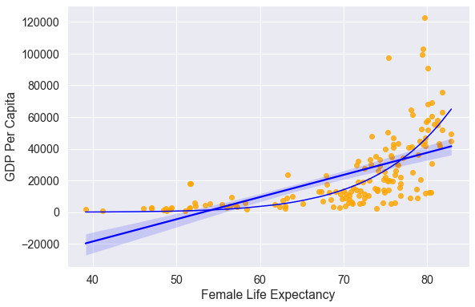

```python
pred_GDP = model.predict(soc_ind)
sns.regplot(x = soc_ind.lifeFemale, y =soc_ind.gdpPerCapita,color = 'orange', line_kws = {'color':'blue'})
sns.lineplot(x = soc_ind.lifeFemale, y = pred_GDP, color = 'blue')
plt.xlabel('Female Life Expectancy')
plt.ylabel('GDP Per Capita')
```

### Training MLR with qualitative predictor

Develop a model to predict `gdpPerCapita` with $P$ and `continent` as predictors.

1. Interpert the intercept term.
2. For a given value of $P$, are there any continents that **do not** have a signficant difference between their mean `gdpPerCapita` and that of Africa? If yes, then which ones, and why? If no, then why not? Consider a significance level of 5%.

*(4 + 4 points)*

```python
model = smf.ols(formula = 'gdpPerCapita~lifeFemale+continent', data = soc_ind).fit()
print(model.summary())
```

```
                            OLS Regression Results
==============================================================================
Dep. Variable:           gdpPerCapita   R-squared:                       0.508
Model:                            OLS   Adj. R-squared:                  0.488
Method:                 Least Squares   F-statistic:                     25.43
Date:                Sun, 29 Jan 2023   Prob (F-statistic):           1.28e-20
Time:                        19:48:39   Log-Likelihood:                -1723.6
No. Observations:                 155   AIC:                             3461.
Df Residuals:                     148   BIC:                             3483.
Df Model:                           6
Covariance Type:            nonrobust
==============================================================================================
                                 coef    std err          t      P>|t|      [0.025      0.975]
----------------------------------------------------------------------------------------------
Intercept                  -7.208e+04   1.14e+04     -6.305      0.000   -9.47e+04   -4.95e+04
continent[T.Asia]           1324.7980   4805.099      0.276      0.783   -8170.667    1.08e+04
continent[T.Europe]         9167.0203   5785.650      1.584      0.115   -2266.134    2.06e+04
continent[T.North America] -1.446e+04   5947.502     -2.431      0.016   -2.62e+04   -2704.270
continent[T.Oceania]       -1.429e+04   6063.764     -2.357      0.020   -2.63e+04   -2307.304
continent[T.South America] -1.329e+04   6462.516     -2.056      0.042   -2.61e+04    -516.198
lifeFemale                  1393.4213    194.062      7.180      0.000    1009.931    1776.911
==============================================================================
Omnibus:                       67.873   Durbin-Watson:                   1.942
Prob(Omnibus):                  0.000   Jarque-Bera (JB):              231.081
Skew:                           1.701   Prob(JB):                     6.63e-51
Kurtosis:                       7.920   Cond. No.                         721.
==============================================================================

Notes:
[1] Standard Errors assume that the covariance matrix of the errors is correctly specified.
```

#### For the hypothetical scenario of a country with zero female life expectancy and from the African continent, the estimated mean GDP per capita is roughly equal to -7.208e+04 or -72,080.

#### Based on the model summary, the two continents that do not have a significant difference between their mean GDP per capita and that of Africa are Asia and Europe. The p-values of these continents can be interpreted in relation to the baseline level of the continent categorical variable which is Africa. Thus, the p-values of these continents are greater than 0.05 meaning we cannot conclude their mean GDP per capita is significantly different from Africa.

### Variable interaction

The model developed in the previous question has a limitation. It assumes that the increase in mean `gdpPerCapita` with a unit increase in $P$ does not depend on the `continent`.

1. Eliminate this limitation by including interaction of `continent` with $P$ in the model developed in the previous question. Print the model summary of the model with interactions.
2. Interpret the coefficient of any one of the interaction terms. *(4 + 4 points)*

```python
model = smf.ols(formula = 'gdpPerCapita~lifeFemale*continent', data = soc_ind).fit()
print(model.summary())
```

```
                            OLS Regression Results
==============================================================================
Dep. Variable:           gdpPerCapita   R-squared:                       0.605
Model:                            OLS   Adj. R-squared:                  0.574
Method:                 Least Squares   F-statistic:                     19.90
Date:                Sun, 29 Jan 2023   Prob (F-statistic):           7.99e-24
Time:                        19:48:44   Log-Likelihood:                -1706.6
No. Observations:                 155   AIC:                             3437.
Df Residuals:                     143   BIC:                             3474.
Df Model:                          11
Covariance Type:            nonrobust
=========================================================================================================
                                            coef    std err          t      P>|t|      [0.025      0.975]
---------------------------------------------------------------------------------------------------------
Intercept                             -1.723e+04   1.53e+04     -1.129      0.261   -4.74e+04    1.29e+04
continent[T.Asia]                     -1.094e+05   2.63e+04     -4.156      0.000   -1.61e+05   -5.74e+04
continent[T.Europe]                   -2.774e+05   6.63e+04     -4.185      0.000   -4.08e+05   -1.46e+05
continent[T.North America]              -6.6e+04   4.88e+04     -1.352      0.178   -1.62e+05    3.05e+04
continent[T.Oceania]                  -1.367e+05   5.78e+04     -2.364      0.019   -2.51e+05   -2.24e+04
continent[T.South America]            -7830.3082   8.18e+04     -0.096      0.924   -1.69e+05    1.54e+05
lifeFemale                              428.5595    264.214      1.622      0.107     -93.711     950.830
lifeFemale:continent[T.Asia]           1755.1049    400.782      4.379      0.000     962.882    2547.328
lifeFemale:continent[T.Europe]         3944.6364    869.916      4.535      0.000    2225.080    5664.193
lifeFemale:continent[T.North America]   921.1328    667.359      1.380      0.170    -398.031    2240.297
lifeFemale:continent[T.Oceania]        1898.4382    812.766      2.336      0.021     291.851    3505.026
lifeFemale:continent[T.South America]   135.3138   1134.388      0.119      0.905   -2107.022    2377.650
==============================================================================
Omnibus:                       73.348   Durbin-Watson:                   1.900
Prob(Omnibus):                  0.000   Jarque-Bera (JB):              290.376
Skew:                           1.785   Prob(JB):                     8.82e-64
Kurtosis:                       8.676   Cond. No.                     5.23e+03
==============================================================================

Notes:
[1] Standard Errors assume that the covariance matrix of the errors is correctly specified.
[2] The condition number is large, 5.23e+03. This might indicate that there are
strong multicollinearity or other numerical problems.
```

#### North America: For a one-year increase in female life expectancy, the increase in estimated mean GDP per capita in a country from North America is roughly 921 units more than the increase in estimated mean GDP per capita of a country from the African continent.

### Model visualisation

Use the model developed in the previous question to plot the regression lines for Africa, Asia, and Europe. Put `gdpPerCapita` on the vertical axis and $P$ on the horizontal axis. Use a legend to distinguish among the regression lines of the three continents.

*(4 points)*

[figure not shown]

```python
plt.rcParams["figure.figsize"] = (9,6)
sns.set(font_scale = 1.3)
x = np.linspace(soc_ind.gdpPerCapita.min(),soc_ind.gdpPerCapita.max(),100)
ax = sns.lineplot(x = x, y = model.params['lifeFemale']*x+model.params['Intercept'], label='Africa', color = 'red')
plt.plot(x, (model.params['lifeFemale']+model.params['lifeFemale:continent[T.Asia]'])*x+model.params['Intercept']+model.params['continent[T.Asia]'], '-b', label='Asia')
plt.plot(x, (model.params['lifeFemale']+model.params['lifeFemale:continent[T.Europe]'])*x+model.params['Intercept']+model.params['continent[T.Europe]'], '-g', label='Europe')
plt.legend(loc='upper left')
plt.xlabel('Female Life Expectancy')
plt.ylabel('Predicted GDP Per Capita')
plt.show()
```

### Model interpretation

Based on the plot develop in the previous question, which continent has the highest increase in mean `gdpPerCapita` for a unit increase in $P$, and which one has the least? Justify your answer.

*(2+2 points)*

#### Based on the visualization above, the continent that has the highest/least increase in mean GDP per Capita for a unit increase in Female Life Expectancy can be determined by comparing the slope of the three continents. Based on these slopes, Europe has the highest mean increase whereas Africa has the lowest.